# Requirements for co-publication app at KTH

2021-10-12

## Agenda

- Background
- Brief demo of current ABM
- Earlier/current ways to get co-publication data at KTH
- Your **questions and feedback**
- Proof-of-concept for co-publication app
- Wrap-up

**Netiquette:**

Please use Zoom, raise hand for questions or write in the chat, mute if not speaking, and think about questions for the Q&A session at the end.

## Background for this meeting

**Aim**

- To show previous examples of co-publication data
- To discuss needs and use-cases that should be covered by an application

**About the project**

In the ABM-project, we have had [previous demo meetings](https://KTH-Library.github.io/demo-6), the latest at 2021-03-25.  
The project is working by an agile model with 2 week sprints.  
From this summer the project has worked with a wider scope, to include more data sources and data flows.

## Copublications app

**Goal:**

1. Present co-publication from KTH through an interactive app
2. Answer frequently posed questions related to networks of KTH publications
3. Allow the ability to view data at different organization levels and at author-name level  
   …
4. Automate and simplify analysis

## Current ABM

**ABM 2019** (2013-2019): https://abm.sys.kth.se/public/

Now with basic co-publication data added .

## Earlier examples of presentations and access

- [KTH Co-publication page](https://www.kth.se/bibliometrics/KTH/copublishing/KTH_countries_2015_2019/index.html)
- Specific requests to the bibliometric group
- Bibliometric presentations to departments
- Online publication databases(?)

## “Standard” co-publication request

How much is KTH collaborating with organization X, and which departments and researchers are involved?  
How much is KTH collaborating with country Y?

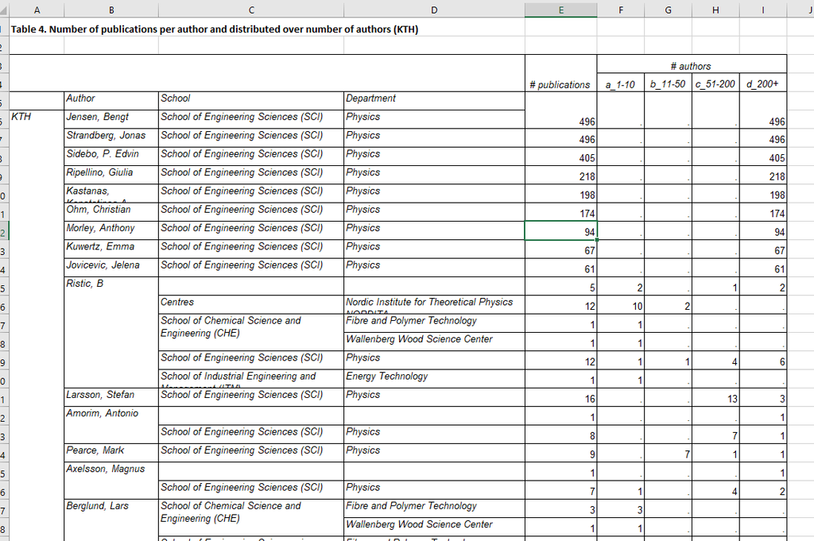

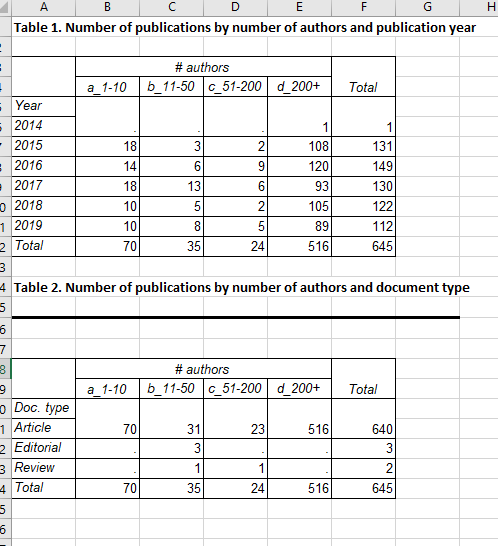

## “Standard” co-publication request 2

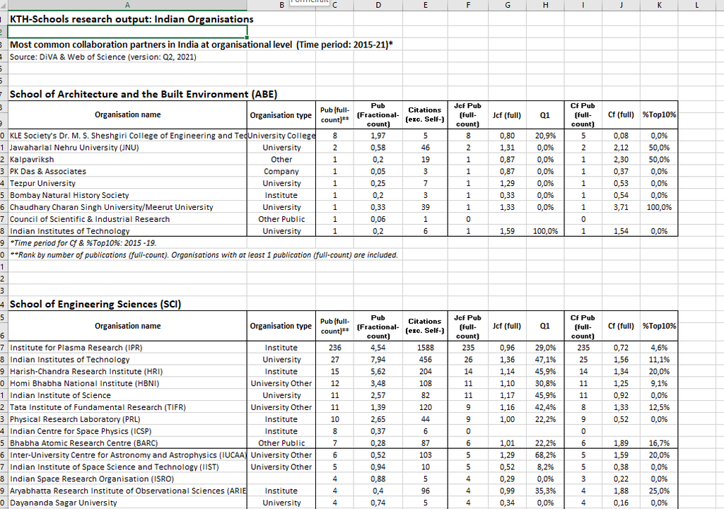

Note: Including some bibliometric indicators along with publication volumes.

## Networks, organization-level

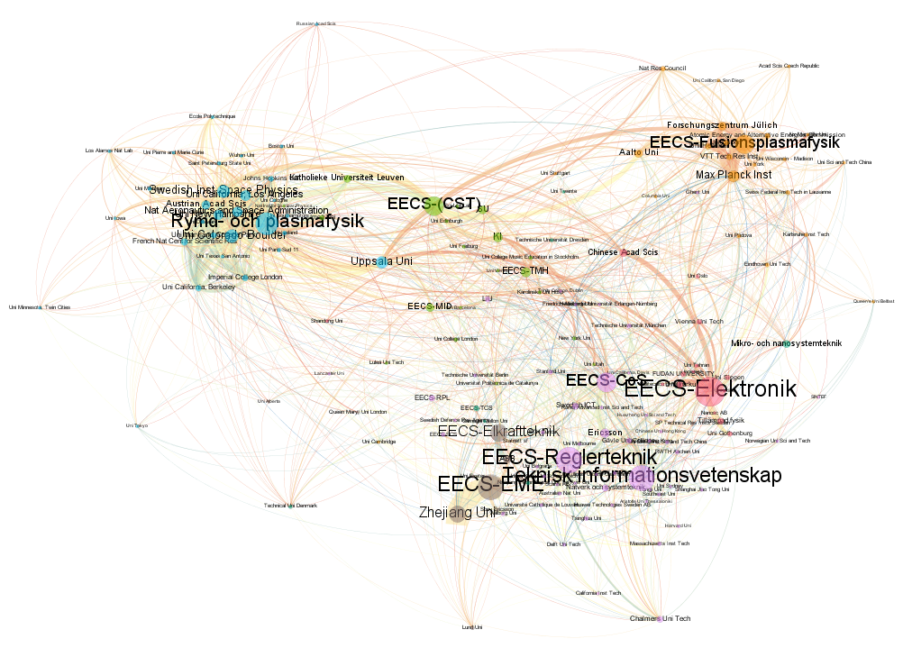

## Networks, within collaboration

[figure not shown]

## Networks, subject-wise / keywords

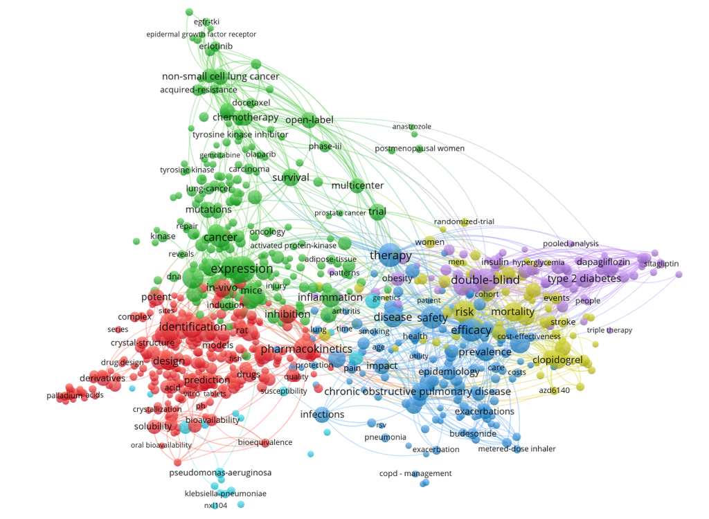

## Questions

## What are your needs?

- Filter on other organization?
- Limit on colloboration size?
- Filter on subject category?
- Use of maps and networks?
- Need for citation and journal indicators?
- App for interal or external use (or both)?

What needs do you see for presenting **collaboration and co-publication** data?  
Suggestions and **comments**

**Questions** from the Zoom chat

## Demo of KTH co-publication app

Draft co-publication app for KTH at https://bibliometrics.lib.kth.se/apps/reports/bibliotools/kth_copub/

- Early proof-on-concept
- Basic functionality, app-publishing and data flow.

## Co-publ app - screenshot

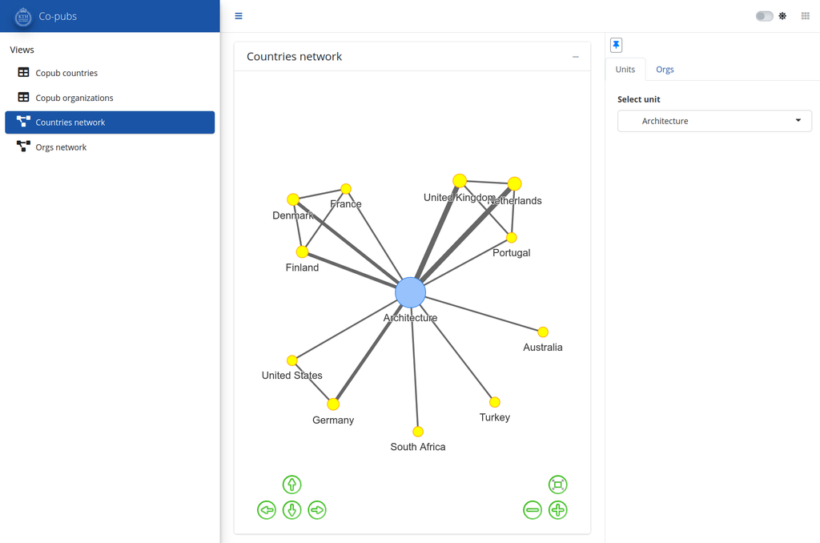

## Next steps

We will gather input and might contact some of you for further information

Other comments?

tjep@kth.se, lidehn@kth.se

Thank you for attending!